# compositePRS

This QMD trains composite PRS models in ADGC, compares plain logistic/ridge/elastic-net models, tests whether the ADGC-trained composite PRS predicts cognitive impairment in HABS-HD, tests whether the HABS-HD composite PRS relates to plasma biomarkers, and evaluates which individual PRSs contribute most through leave-one-out analysis.

Loads config.yaml config controls seed ADGC input paths HABS-HD input paths PRS folder names results directory

R/helpers.R –> package loading, trait labels, PRS variable definitions, config helpers

R/load_data.R –> ADGC/HABS-HD data loading and PRS merging

R/models.R –> model-fitting functions

R/exports.R –> Excel/table export functions

R/plots.R –> plotting functions

1. ADGC PLINK family/sample file: /wynton/group/andrews/users/rakshyasharma/PRS/PRS-CS-Auto/resources/ADGC/adgc.fam
2. ADGC covariate file: /wynton/group/andrews/data/adgc/ADGCdatasets/covar_covariates.tsv
3. ADGC pgsc_calc PRS result folders: /wynton/group/andrews/users/rakshyasharma/pgsc_calc/adgc/results/ADGC

Graham2021tc_eur Graham2021TG_eur Graham2021HDL_eur Graham2021LDL_eur Keaton2024diaBP Keaton2024PP Keaton2024sysBP Okbay2022educ SaundersDrnkwk SaundersSmkInt SuzukiDia2024 YengoBMI2018 Socrates2024 Trpchevska2022 Choquet2021 Klimentidis2018mvpa Adams2025mdd

reads the already-built shared master file: habshd_master_df <- readRDS( “/wynton/group/andrews/users/rakshyasharma/PRS/shared_data/habshd_master_df.rds” )

train_df –> 70% ADGC training data, cases and controls sampled separately

test_df –> 30% ADGC held-out test data

train_df_F –> female-only ADGC training data

test_df_F –> female-only ADGC test data

train_df_M –> male-only ADGC training data

test_df_M –> male-only ADGC test data

adgc_df_prs.rds –> Full ADGC PRS analysis dataset

habshd_eval.rds –> Filtered HABS-HD external validation dataset

plain_total.rds –> Total-sample plain logistic composite PRS model object

plain_female.rds –> Female-only plain logistic composite PRS model object

plain_male.rds –> Male-only plain logistic composite PRS model object

plain_results.rds –> Plain logistic model summary results

ridge_results.rds –> Ridge model summary results

enet_results.rds –> Elastic-net model summary results

compare_results.rds –> Combined plain/ridge/elastic-net comparison results

hab_results.rds –> HABS-HD external validation results

endo_results.rds –> Composite PRS biomarker/endophenotype results in HABS-HD

loo_adgc_results.rds –> ADGC leave-one-PRS-out results

loo_hab_results.rds –> HABS-HD leave-one-PRS-out results

Composite PRS model results ADGC train/test model results Ridge and elastic net comparison results External HABS-HD validation results HABS-HD biomarker endophenotype results Leave-one-PRS-out sensitivity results Table 1 outputs Figures RDS objects Excel workbook

output tree results/ ├── Composite_PRS_main_results.xlsx │ ├── rds/ │ ├── adgc_df_prs.rds │ ├── habshd_eval.rds │ ├── plain_total.rds │ ├── plain_female.rds │ ├── plain_male.rds │ ├── plain_results.rds │ ├── ridge_results.rds │ ├── enet_results.rds │ ├── compare_results.rds │ ├── hab_results.rds │ ├── endo_results.rds │ ├── loo_adgc_results.rds │ └── loo_hab_results.rds │ ├── tables/ │ ├── ADGC_table1_analytic_sample.docx │ ├── HABSHD_table1_analytic_sample.docx │ ├── ADGC_table1_analytic_sample.rtf │ └── HABSHD_table1_analytic_sample.rtf │ └── figures/ ├── adgc_model_comparison.png ├── habs_main_results.png ├── endophenotypes.png ├── loo_adgc.png └── loo_hab.png

flow chart

config.yml + R helper scripts | v Load ADGC sample/covariate/PRS data | v adgc_df_prs | v 70/30 stratified train-test split | v Train composite PRS models in ADGC | |– Plain logistic |– Ridge |– Elastic net | v ADGC held-out model comparison | v compare_results | v Read HABS-HD master dataset | v habshd_eval | v Apply ADGC-trained composite PRS to HABS-HD | v hab_results | v Run composite PRS biomarker models in HABS-HD | v endo_results | v Run leave-one-PRS-out analyses | |– loo_adgc_results |– loo_hab_results | v Export RDS files, Excel workbook, Table 1 files, and figures

```r
target_lib <- "/wynton/home/andrews/rakshyasharma/R/rocky8-x86_64-pc-linux-gnu-library/4.4-CBI-gcc13"

.libPaths(c(target_lib, .libPaths()))

cat("R version:", R.version.string, "\n")
```

```
## R version: R version 4.5.3 (2026-03-11)
```

```r
cat("Library paths used by compositePRS.qmd:\n")
```

```
## Library paths used by compositePRS.qmd:
```

```r
print(.libPaths())
```

```
## [1] "/wynton/home/andrews/rakshyasharma/R/rocky8-x86_64-pc-linux-gnu-library/4.4-CBI-gcc13"
## [2] "/wynton/home/andrews/rakshyasharma/R/rocky8-x86_64-pc-linux-gnu-library/4.5-CBI-gcc13"
## [3] "/wynton/home/cbi/shared/software/CBI/_rocky8/R-4.5.3-gcc13/lib64/R/library"
```

```r
cat("openxlsx available:", requireNamespace("openxlsx", quietly = TRUE), "\n")
```

```
## openxlsx available: TRUE
```

```r
source("R/helpers.R")
source("R/load_data.R")
source("R/models.R")
source("R/exports.R")
source("R/plots.R")

load_required_packages()
cfg <- load_project_config("config.yml")

set.seed(cfg$seed)
```

```r
adgc_df_prs <- load_adgc_data(
  fam_file = cfg$paths$fam_file,
  covar_file = cfg$paths$covar_file,
  base_dir = cfg$paths$adgc_base_dir,
  folder_names = cfg$folder_names,
  trait_labels = trait_labels,
  all_prs_vars = all_prs_vars
)

cat("Rows in ADGC analysis dataset:", nrow(adgc_df_prs), "\n")
```

```
## Rows in ADGC analysis dataset: 27751
```

```r
cat("Columns in ADGC analysis dataset:", ncol(adgc_df_prs), "\n")
```

```
## Columns in ADGC analysis dataset: 73
```

```r
case_ids <- adgc_df_prs %>% dplyr::filter(status_binary == 1) %>% dplyr::pull(ID_2)
control_ids <- adgc_df_prs %>% dplyr::filter(status_binary == 0) %>% dplyr::pull(ID_2)

train_case_ids <- sample(case_ids, size = floor(0.7 * length(case_ids)))
train_control_ids <- sample(control_ids, size = floor(0.7 * length(control_ids)))
train_ids <- c(train_case_ids, train_control_ids)

train_df <- adgc_df_prs %>% dplyr::filter(ID_2 %in% train_ids)
test_df  <- adgc_df_prs %>% dplyr::filter(!ID_2 %in% train_ids)

train_df_F <- train_df %>% dplyr::filter(Sex == 2)
test_df_F  <- test_df %>% dplyr::filter(Sex == 2)

train_df_M <- train_df %>% dplyr::filter(Sex == 1)
test_df_M  <- test_df %>% dplyr::filter(Sex == 1)

cat("Train rows:", nrow(train_df), "\n")
```

```
## Train rows: 19425
```

```r
cat("Test rows:", nrow(test_df), "\n")
```

```
## Test rows: 8326
```

```r
plain_total  <- fit_plain_cprs(train_df,   test_df,   all_prs_vars, "Total",  TRUE)
plain_female <- fit_plain_cprs(train_df_F, test_df_F, all_prs_vars, "Female", FALSE)
plain_male   <- fit_plain_cprs(train_df_M, test_df_M, all_prs_vars, "Male",   FALSE)
plain_results <- dplyr::bind_rows(
  plain_total$result,
  plain_female$result,
  plain_male$result
)

plain_results %>%
  dplyr::select(sex_strata, estimate, conf.low, conf.high, p.value, test_auc)
```

```
## # A tibble: 3 × 6
##   sex_strata estimate conf.low conf.high       p.value test_auc
##   <chr>         <dbl>    <dbl>     <dbl>         <dbl>    <dbl>
## 1 Total          1.16     1.11      1.22 0.00000000119    0.541
## 2 Female         1.17     1.10      1.24 0.00000126       0.550
## 3 Male           1.12     1.03      1.20 0.00432          0.518
```

```r
ridge_total  <- fit_penalized_cprs(train_df,   test_df,   all_prs_vars, 0,   "Total",  TRUE,  "Ridge")
ridge_female <- fit_penalized_cprs(train_df_F, test_df_F, all_prs_vars, 0,   "Female", FALSE, "Ridge")
ridge_male   <- fit_penalized_cprs(train_df_M, test_df_M, all_prs_vars, 0,   "Male",   FALSE, "Ridge")

enet_total   <- fit_penalized_cprs(train_df,   test_df,   all_prs_vars, 0.5, "Total",  TRUE,  "Elastic net")
enet_female  <- fit_penalized_cprs(train_df_F, test_df_F, all_prs_vars, 0.5, "Female", FALSE, "Elastic net")
enet_male    <- fit_penalized_cprs(train_df_M, test_df_M, all_prs_vars, 0.5, "Male",   FALSE, "Elastic net")

ridge_results <- dplyr::bind_rows(ridge_total$result, ridge_female$result, ridge_male$result)
enet_results  <- dplyr::bind_rows(enet_total$result, enet_female$result, enet_male$result)

compare_results <- dplyr::bind_rows(
  plain_results,
  ridge_results,
  enet_results
) %>%
  dplyr::mutate(
    sex_strata = factor(sex_strata, levels = c("Total", "Male", "Female")),
    model = factor(model, levels = c("Plain logistic", "Ridge", "Elastic net"))
  )

compare_results %>%
  dplyr::select(sex_strata, model, estimate, conf.low, conf.high, p.value, test_auc)
```

```
## # A tibble: 9 × 7
##   sex_strata model          estimate conf.low conf.high  p.value test_auc
##   <fct>      <fct>             <dbl>    <dbl>     <dbl>    <dbl>    <dbl>
## 1 Total      Plain logistic     1.16     1.11      1.22 1.19e- 9    0.541
## 2 Female     Plain logistic     1.17     1.10      1.24 1.26e- 6    0.550
## 3 Male       Plain logistic     1.12     1.03      1.20 4.32e- 3    0.518
## 4 Total      Ridge              1.17     1.11      1.23 2.40e-10    0.544
## 5 Female     Ridge              1.17     1.10      1.25 9.66e- 7    0.550
## 6 Male       Ridge              1.14     1.05      1.23 1.06e- 3    0.524
## 7 Total      Elastic net        1.16     1.11      1.22 7.56e-10    0.543
## 8 Female     Elastic net        1.17     1.10      1.24 1.37e- 6    0.550
## 9 Male       Elastic net        1.12     1.04      1.21 2.56e- 3    0.520
```

```r
habshd_master_df <- readRDS("/wynton/group/andrews/users/rakshyasharma/PRS/shared_data/habshd_master_df.rds")

habshd_eval <- habshd_master_df %>%
  dplyr::mutate(
    Sex = dplyr::case_when(
      ID_Gender == 0 ~ 1L,  # Male in ADGC coding
      ID_Gender == 1 ~ 2L,  # Female in ADGC coding
      TRUE ~ NA_integer_
    )
  ) %>%
  dplyr::filter(
    !is.na(cognitive_impairment),
    !is.na(Age),
    !is.na(APOE4_Positivity),
    !is.na(Race),
    !is.na(PC1), !is.na(PC2), !is.na(PC3), !is.na(PC4),
    !is.na(ID_Gender),
    !is.na(Sex)
  )
```

```r
hab_total_obj <- score_external_habshd(
  hab_data = habshd_eval,
  model_obj = plain_total,
  outcome_var = "cognitive_impairment",
  sex_subset = NULL,
  sex_group = "Total"
)

hab_female_obj <- score_external_habshd(
  hab_data = habshd_eval,
  model_obj = plain_female,
  outcome_var = "cognitive_impairment",
  sex_subset = 2,
  sex_group = "Female"
)

hab_male_obj <- score_external_habshd(
  hab_data = habshd_eval,
  model_obj = plain_male,
  outcome_var = "cognitive_impairment",
  sex_subset = 1,
  sex_group = "Male"
)

hab_results <- dplyr::bind_rows(
  hab_total_obj$result,
  hab_female_obj$result,
  hab_male_obj$result
)

hab_results %>%
  dplyr::select(group, estimate, conf.low, conf.high, p.value, test_auc)
```

```
## # A tibble: 3 × 6
##   group  estimate conf.low conf.high p.value test_auc
##   <chr>     <dbl>    <dbl>     <dbl>   <dbl>    <dbl>
## 1 Total      1.09    1.01       1.18  0.0370    0.524
## 2 Female     1.09    0.979      1.22  0.114     0.529
## 3 Male       1.11    0.988      1.24  0.0815    0.529
```

```r
hab_total_scored  <- hab_total_obj$data
hab_female_scored <- hab_female_obj$data
hab_male_scored   <- hab_male_obj$data

endo_results <- run_endophenotype_models(
  hab_total_scored = hab_total_scored,
  hab_female_scored = hab_female_scored,
  hab_male_scored = hab_male_scored
)

endo_results %>%
  dplyr::select(group, outcome, estimate, conf.low, conf.high, p.value, p_adj_fdr)
```

```
## # A tibble: 15 × 7
##    group  outcome   estimate conf.low conf.high p.value p_adj_fdr
##    <chr>  <chr>        <dbl>    <dbl>     <dbl>   <dbl>     <dbl>
##  1 Total  ptau181    0.00636 -0.0274     0.0401 0.712      0.881
##  2 Total  ptau217    0.0178  -0.0171     0.0528 0.317      0.563
##  3 Total  ab42_ab40 -0.0180  -0.0549     0.0188 0.338      0.563
##  4 Total  nfl        0.0276  -0.00495    0.0601 0.0965     0.483
##  5 Total  tau       -0.00279 -0.0393     0.0337 0.881      0.881
##  6 Female ptau181   -0.0252  -0.0657     0.0153 0.222      0.613
##  7 Female ptau217   -0.0201  -0.0646     0.0244 0.376      0.627
##  8 Female ab42_ab40 -0.0286  -0.0769     0.0197 0.245      0.613
##  9 Female nfl       -0.00808 -0.0499     0.0338 0.705      0.724
## 10 Female tau       -0.00877 -0.0574     0.0399 0.724      0.724
## 11 Male   ptau181    0.0288  -0.0286     0.0862 0.326      0.543
## 12 Male   ptau217    0.0294  -0.0261     0.0848 0.299      0.543
## 13 Male   ab42_ab40 -0.0190  -0.0748     0.0369 0.505      0.631
## 14 Male   nfl        0.0763   0.0260     0.126  0.00297    0.0148
## 15 Male   tau       -0.00229 -0.0556     0.0511 0.933      0.933
```

```r
loo_adgc_total <- run_loo_plain_adgc(train_df,   test_df,   all_prs_vars, include_sex = TRUE,  sex_group = "Total")
loo_adgc_female <- run_loo_plain_adgc(train_df_F, test_df_F, all_prs_vars, include_sex = FALSE, sex_group = "Female")
loo_adgc_male <- run_loo_plain_adgc(train_df_M, test_df_M, all_prs_vars, include_sex = FALSE, sex_group = "Male")
loo_adgc_results <- dplyr::bind_rows(
  loo_adgc_total,
  loo_adgc_female,
  loo_adgc_male
)

loo_hab_total <- run_loo_habshd(
  train_df = train_df,
  test_df = test_df,
  hab_data = habshd_eval,
  prs_vars = all_prs_vars
)

loo_hab_female <- run_loo_habshd_sex(
  train_df = train_df_F,
  test_df = test_df_F,
  hab_data = habshd_eval,
  prs_vars = all_prs_vars,
  sex_code = 2,
  sex_group = "Female"
)

loo_hab_male <- run_loo_habshd_sex(
  train_df = train_df_M,
  test_df = test_df_M,
  hab_data = habshd_eval,
  prs_vars = all_prs_vars,
  sex_code = 1,
  sex_group = "Male"
)
loo_hab_results <- dplyr::bind_rows(
  loo_hab_total,
  loo_hab_female,
  loo_hab_male
)

loo_adgc_results %>% dplyr::slice_head(n = 5)
```

```
## # A tibble: 5 × 13
##   term       estimate std.error statistic  p.value conf.low conf.high sex_strata
##   <chr>         <dbl>     <dbl>     <dbl>    <dbl>    <dbl>     <dbl> <chr>
## 1 comp_scor…     1.17    0.0247      6.46 1.05e-10     1.12      1.23 Total
## 2 comp_scor…     1.08    0.0243      3.25 1.15e- 3     1.03      1.14 Total
## 3 comp_scor…     1.17    0.0247      6.24 4.32e-10     1.11      1.22 Total
## 4 comp_scor…     1.16    0.0247      6.14 8.49e-10     1.11      1.22 Total
## 5 comp_scor…     1.17    0.0247      6.31 2.80e-10     1.11      1.23 Total
## # ℹ 5 more variables: model <chr>, train_score_sd <dbl>, test_auc <dbl>,
## #   dropped_prs <chr>, n_prs <int>
```

```r
loo_hab_results %>% dplyr::slice_head(n = 5)
```

```
## # A tibble: 5 × 11
##   term    estimate std.error statistic p.value conf.low conf.high group test_auc
##   <chr>      <dbl>     <dbl>     <dbl>   <dbl>    <dbl>     <dbl> <chr>    <dbl>
## 1 comp_s…     1.10    0.0412      2.30  0.0215    1.01       1.19 Total    0.527
## 2 comp_s…     1.05    0.0409      1.18  0.238     0.969      1.14 Total    0.522
## 3 comp_s…     1.09    0.0418      2.03  0.0429    1.00       1.18 Total    0.524
## 4 comp_s…     1.09    0.0416      2.04  0.0414    1.00       1.18 Total    0.524
## 5 comp_s…     1.08    0.0407      1.95  0.0510    1.00       1.17 Total    0.521
## # ℹ 2 more variables: dropped_prs <chr>, n_prs <int>
```

```r
full_adgc_plot <- plain_results %>%
  dplyr::mutate(
    dropped_prs = "Full composite",
    sex_strata = factor(sex_strata, levels = c("Total", "Female", "Male"))
  ) %>%
  dplyr::select(sex_strata, dropped_prs, estimate, conf.low, conf.high, p.value, test_auc)

loo_adgc_plot_df <- dplyr::bind_rows(
  full_adgc_plot,
  loo_adgc_results %>%
    dplyr::mutate(sex_strata = factor(sex_strata, levels = c("Total", "Female", "Male"))) %>%
    dplyr::select(sex_strata, dropped_prs, estimate, conf.low, conf.high, p.value, test_auc)
) %>%
  dplyr::mutate(
    dropped_prs = factor(
      dropped_prs,
      levels = c("Full composite", rev(unique(loo_adgc_results$dropped_prs)))
    )
  )

full_hab_plot <- hab_results %>%
  dplyr::mutate(
    dropped_prs = "Full composite",
    group = factor(group, levels = c("Total", "Female", "Male"))
  ) %>%
  dplyr::select(group, dropped_prs, estimate, conf.low, conf.high, p.value, test_auc)

loo_hab_plot_df <- dplyr::bind_rows(
  full_hab_plot,
  loo_hab_results %>%
    dplyr::mutate(group = factor(group, levels = c("Total", "Female", "Male"))) %>%
    dplyr::select(group, dropped_prs, estimate, conf.low, conf.high, p.value, test_auc)
) %>%
  dplyr::mutate(
    dropped_prs = factor(
      dropped_prs,
      levels = c("Full composite", rev(unique(loo_hab_results$dropped_prs)))
    )
  )
```

```r
dir.create(file.path(cfg$paths$results_dir, "rds"), recursive = TRUE, showWarnings = FALSE)

saveRDS(adgc_df_prs, file.path(cfg$paths$results_dir, "rds", "adgc_df_prs.rds"))
saveRDS(habshd_eval, file.path(cfg$paths$results_dir, "rds", "habshd_eval.rds"))

saveRDS(plain_total, file.path(cfg$paths$results_dir, "rds", "plain_total.rds"))
saveRDS(plain_female, file.path(cfg$paths$results_dir, "rds", "plain_female.rds"))
saveRDS(plain_male, file.path(cfg$paths$results_dir, "rds", "plain_male.rds"))

saveRDS(plain_results, file.path(cfg$paths$results_dir, "rds", "plain_results.rds"))
saveRDS(ridge_results, file.path(cfg$paths$results_dir, "rds", "ridge_results.rds"))
saveRDS(enet_results, file.path(cfg$paths$results_dir, "rds", "enet_results.rds"))
saveRDS(compare_results, file.path(cfg$paths$results_dir, "rds", "compare_results.rds"))
saveRDS(hab_results, file.path(cfg$paths$results_dir, "rds", "hab_results.rds"))
saveRDS(endo_results, file.path(cfg$paths$results_dir, "rds", "endo_results.rds"))
saveRDS(loo_adgc_results, file.path(cfg$paths$results_dir, "rds", "loo_adgc_results.rds"))
saveRDS(loo_hab_results, file.path(cfg$paths$results_dir, "rds", "loo_hab_results.rds"))
```

```r
xlsx_out <- file.path(cfg$paths$results_dir, "Composite_PRS_main_results.xlsx")

export_main_results_xlsx(
  plain_results = plain_results,
  ridge_results = ridge_results,
  enet_results = enet_results,
  compare_results = compare_results,
  hab_results = hab_results,
  output_file = xlsx_out
)

cat("Workbook written to:", xlsx_out, "\n")
```

```
## Workbook written to: results/Composite_PRS_main_results.xlsx
```

## ADGC Table 1

```r
library(gtsummary)
library(flextable)
library(gt)

adgc_table1_data <- adgc_df_prs %>%
  dplyr::transmute(
    Sex = factor(Sex, levels = c(1, 2), labels = c("Male", "Female")),
    Status = factor(status, levels = c(1, 2), labels = c("Cognitively Unimpaired", "Alzheimer's Disease")),
    Age = aaoaae,
    APOE4 = factor(apoe4any, levels = c(0, 1), labels = c("Negative", "Positive")),
    Ancestry = MostSimilarPop
  )

adgc_table1_summary <- adgc_table1_data %>%
  tbl_summary(
    by = Sex,
    statistic = list(
      all_continuous() ~ "{mean} ({sd})",
      all_categorical() ~ "{n} / {N} ({p}%)"
    ),
    missing = "no"
  ) %>%
  add_overall() %>%
  modify_caption("**Table 1. Baseline characteristics of the ADGC analytic sample**")

adgc_table1_summary
```

**Table 1. Baseline characteristics of the ADGC analytic sample**

| **Characteristic** | **Overall** N = 27,751<sup>1</sup> | **Male** N = 10,959<sup>1</sup> | **Female** N = 16,792<sup>1</sup> |
| --- | --- | --- | --- |
| Status |  |  |  |
| Cognitively Unimpaired | 17,219 / 27,751 (62%) | 6,613 / 10,959 (60%) | 10,606 / 16,792 (63%) |
| Alzheimer's Disease | 10,532 / 27,751 (38%) | 4,346 / 10,959 (40%) | 6,186 / 16,792 (37%) |
| Age | 75 (12) | 75 (12) | 75 (11) |
| APOE4 |  |  |  |
| Negative | 17,109 / 27,751 (62%) | 6,752 / 10,959 (62%) | 10,357 / 16,792 (62%) |
| Positive | 10,642 / 27,751 (38%) | 4,207 / 10,959 (38%) | 6,435 / 16,792 (38%) |
| Ancestry |  |  |  |
| AFR | 1,857 / 27,751 (6.7%) | 467 / 10,959 (4.3%) | 1,390 / 16,792 (8.3%) |
| AMR | 1,865 / 27,751 (6.7%) | 581 / 10,959 (5.3%) | 1,284 / 16,792 (7.6%) |
| CSA | 9 / 27,751 (<0.1%) | 3 / 10,959 (<0.1%) | 6 / 16,792 (<0.1%) |
| EAS | 1,798 / 27,751 (6.5%) | 638 / 10,959 (5.8%) | 1,160 / 16,792 (6.9%) |
| EUR | 22,059 / 27,751 (79%) | 9,201 / 10,959 (84%) | 12,858 / 16,792 (77%) |
| MID | 163 / 27,751 (0.6%) | 69 / 10,959 (0.6%) | 94 / 16,792 (0.6%) |

<sup>1</sup> n / N (%); Mean (SD)

## HABS-HD Table 1

```r
library(gtsummary)
library(flextable)
library(gt)

habshd_table1_data <- habshd_eval %>%
  dplyr::transmute(
    Sex = factor(ID_Gender, levels = c(0, 1), labels = c("Male", "Female")),
    Cognitive_Impairment = factor(cognitive_impairment, levels = c(0, 1), labels = c("No", "Yes")),
    Age = Age,
    Race = Race,
    APOE4 = factor(APOE4_Positivity, levels = c(0, 1), labels = c("Negative", "Positive"))
  )

habshd_table1_summary <- habshd_table1_data %>%
  tbl_summary(
    by = Sex,
    statistic = list(
      all_continuous() ~ "{mean} ({sd})",
      all_categorical() ~ "{n} / {N} ({p}%)"
    ),
    missing = "no"
  ) %>%
  add_overall() %>%
  modify_caption("**Table 2. Baseline characteristics of the HABS-HD analytic sample**")

habshd_table1_summary
```

**Table 2. Baseline characteristics of the HABS-HD analytic sample**

| **Characteristic** | **Overall** N = 3,207<sup>1</sup> | **Male** N = 1,226<sup>1</sup> | **Female** N = 1,981<sup>1</sup> |
| --- | --- | --- | --- |
| Cognitive_Impairment | 863 / 3,207 (27%) | 413 / 1,226 (34%) | 450 / 1,981 (23%) |
| Age | 66 (9) | 66 (9) | 65 (9) |
| Race |  |  |  |
| Black | 778 / 3,207 (24%) | 288 / 1,226 (23%) | 490 / 1,981 (25%) |
| Hispanic | 1,205 / 3,207 (38%) | 516 / 1,226 (42%) | 689 / 1,981 (35%) |
| NHW | 1,224 / 3,207 (38%) | 422 / 1,226 (34%) | 802 / 1,981 (40%) |
| APOE4 |  |  |  |
| Negative | 2,290 / 3,207 (71%) | 877 / 1,226 (72%) | 1,413 / 1,981 (71%) |
| Positive | 917 / 3,207 (29%) | 349 / 1,226 (28%) | 568 / 1,981 (29%) |

<sup>1</sup> n / N (%); Mean (SD)

## Export Table 1 outputs

```r
dir.create(file.path(cfg$paths$results_dir, "tables"), recursive = TRUE, showWarnings = FALSE)

adgc_table1_flex <- as_flex_table(adgc_table1_summary)
habshd_table1_flex <- as_flex_table(habshd_table1_summary)

flextable::save_as_docx(
  "ADGC Table 1" = adgc_table1_flex,
  path = file.path(cfg$paths$results_dir, "tables", "ADGC_table1_analytic_sample.docx")
)

flextable::save_as_docx(
  "HABS-HD Table 1" = habshd_table1_flex,
  path = file.path(cfg$paths$results_dir, "tables", "HABSHD_table1_analytic_sample.docx")
)

gt::gtsave(
  as_gt(adgc_table1_summary),
  filename = file.path(cfg$paths$results_dir, "tables", "ADGC_table1_analytic_sample.rtf")
)

gt::gtsave(
  as_gt(habshd_table1_summary),
  filename = file.path(cfg$paths$results_dir, "tables", "HABSHD_table1_analytic_sample.rtf")
)
```

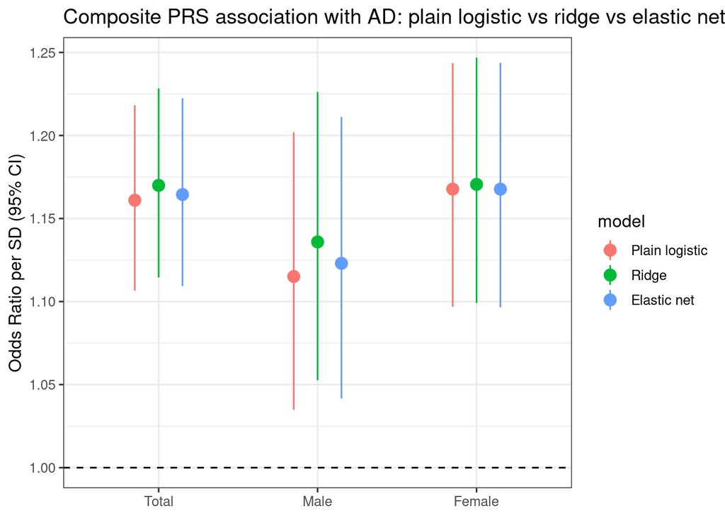

```r
p_adgc_compare <- plot_adgc_model_comparison(compare_results)
p_hab_main <- plot_hab_main_results(hab_results)
p_endo <- plot_endophenotypes(endo_results)
p_loo_adgc <- plot_loo_adgc(loo_adgc_plot_df)
p_loo_hab <- plot_loo_hab(loo_hab_plot_df)

p_adgc_compare
```

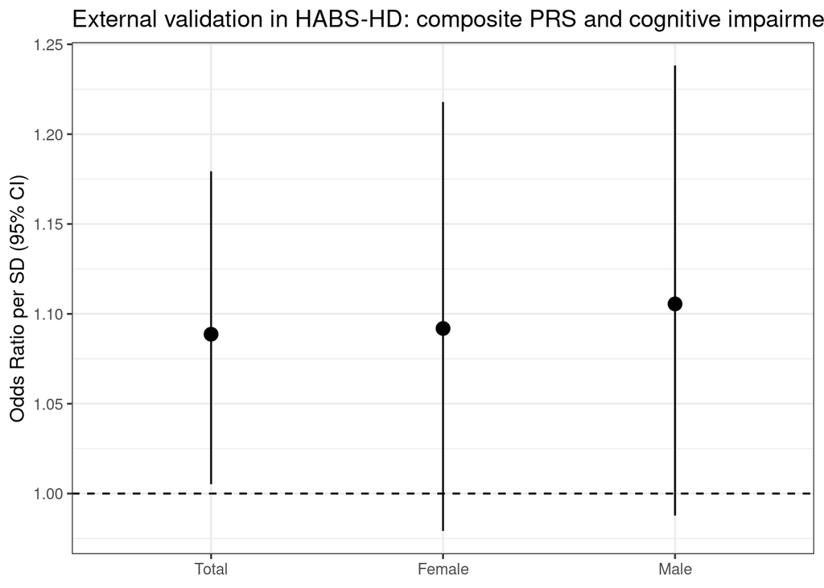

```r
p_hab_main
```

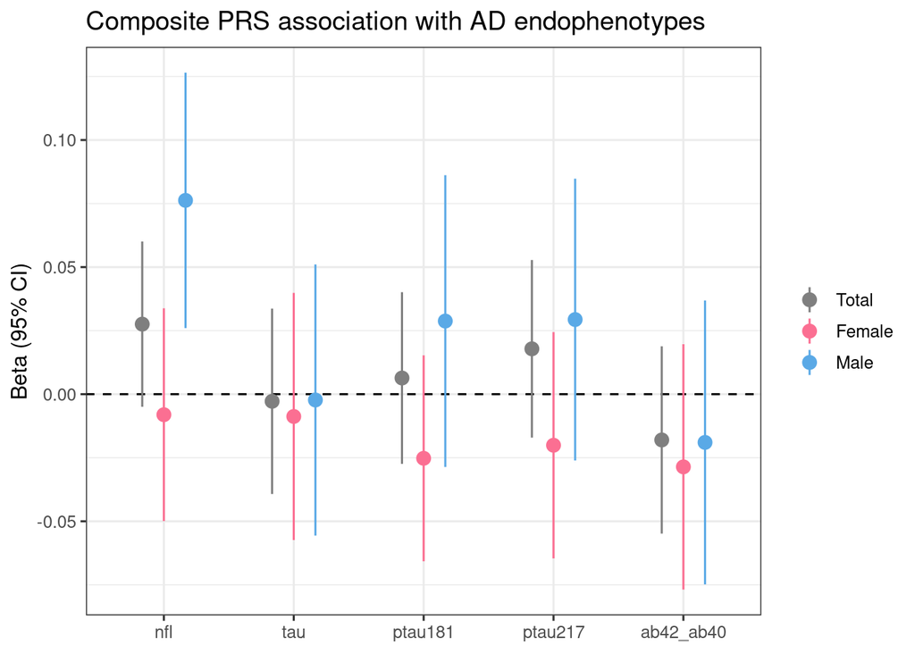

```r
p_endo
```

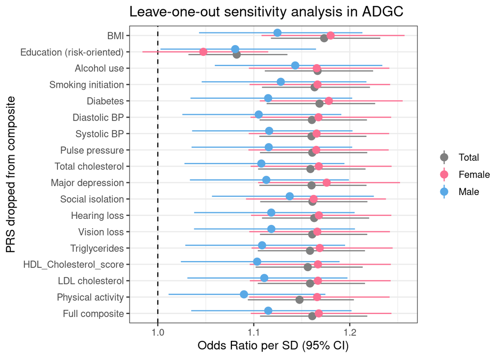

```r
p_loo_adgc
```

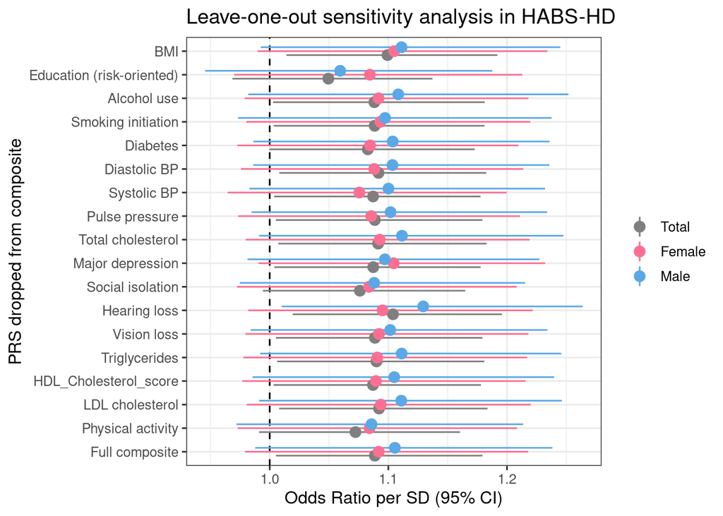

```r
p_loo_hab
```

```r
dir.create(file.path(cfg$paths$results_dir, "figures"), recursive = TRUE, showWarnings = FALSE)

ggplot2::ggsave(
  filename = file.path(cfg$paths$results_dir, "figures", "adgc_model_comparison.png"),
  plot = p_adgc_compare,
  width = 8,
  height = 6,
  dpi = 300
)

ggplot2::ggsave(
  filename = file.path(cfg$paths$results_dir, "figures", "habs_main_results.png"),
  plot = p_hab_main,
  width = 8,
  height = 6,
  dpi = 300
)

ggplot2::ggsave(
  filename = file.path(cfg$paths$results_dir, "figures", "endophenotypes.png"),
  plot = p_endo,
  width = 9,
  height = 6,
  dpi = 300
)

ggplot2::ggsave(
  filename = file.path(cfg$paths$results_dir, "figures", "loo_adgc.png"),
  plot = p_loo_adgc,
  width = 10,
  height = 8,
  dpi = 300
)

ggplot2::ggsave(
  filename = file.path(cfg$paths$results_dir, "figures", "loo_hab.png"),
  plot = p_loo_hab,
  width = 10,
  height = 8,
  dpi = 300
)
```

## Analytic sample checks

```r
cat("ADGC analytic N:", nrow(adgc_df_prs), "\n")
```

```
## ADGC analytic N: 27751
```

```r
cat("HABS-HD analytic N:", nrow(habshd_eval), "\n")
```

```
## HABS-HD analytic N: 3207
```

```r
stopifnot(nrow(adgc_df_prs) == nrow(dplyr::distinct(adgc_df_prs, ID_2)))
stopifnot(nrow(habshd_eval) == nrow(dplyr::distinct(habshd_eval, IID)))
stopifnot(length(intersect(train_df$ID_2, test_df$ID_2)) == 0)
stopifnot(nrow(plain_results) == 3)
stopifnot(nrow(hab_results) == 3)
```